# MASTER MODE : UE MDET : DYNAMIQUES EVOLUTIVES

Encadré par Frédéric Hamelin

Pierre-Alexandre QUITTET & Lucien RICOME

2023

# ———————————————————————————–

# Installation packages (si nécessaire)

Les packages manquants sont à installer si nécessaire. Par défaut, lancer “Knit” les installera tous. Si ce n’est pas désiré, remplacer l’option de chunk **eval = T** par **eval = F**.

```r
install.packages("deSolve", dependencies = T, repos = "https://cran.r-project.org")  # résolution d'EDO
install.packages("rgl", dependencies = T, repos = "https://cran.r-project.org")  # visualisation 3d
install.packages("ggplot2", dependencies = T, repos = "https://cran.r-project.org")
install.packages("tidyverse", dependencies = T, repos = "https://cran.r-project.org")
install.packages("latex2exp", dependencies = T, repos = "https://cran.r-project.org")  # Ecriture LateX
```

# Packages

```r
library(deSolve)  # résolution d'EDO
library(rgl)  # visualisation 3d
library(knitr)  # amélioration graphique Rmarkdown
library(ggplot2)
library(tidyverse)
library(latex2exp)  # Ecriture LateX
```

# Dynamique adaptative : théorie —————————————————-

La dynamique adaptative est un cadre théorique permettant de modéliser l’évolution phénotypique. Elle permet de comprendre les conséquences à long-terme de petites mutations phénotypique sur la trajectoire évolutive des traits considérés. Ce cadre de recherche associe les méthodes de dynamique de population et les concepts de sélection fréquence-dépendance issue de la théorie des jeux (Maynard-Smith, 1973). La sélection fréquence-dépendance s’inscrit dans le paradigme de paysage adaptatif de fitness dynamique, où la fréquence des phénotypes dans la population influence la fitness de ces phénotypes.  
La paradigme de modélisation classique utilisée consiste à considérer une population résidente et une population de mutant à faible densité dont le phénotype diffère légèrement de la population résidente.

L’étude de la dynamique adaptative de phénotypes reposent sur deux idées fondamentales (Brännström et al., 2013) :  
$\quad$ **(1)** la population résidente est supposée être en équilibre dynamique lorsque de nouveaux mutants apparaissent  
$\quad$ **(2)** l’avenir de ces mutants peut être déduit de leur taux de croissance initial lorsqu’ils sont rares dans la population résidente

Ici les populations sont considérées **monomorphiques** : tous les individus d’un même phénotype donnée partagent la même valeur de trait. On considérera également une **reproduction clonale** (les individus donneront naissance à des individus de même trait).

# Modélisation de la dynamique évolutive à 2 espèces ————————————————————————–

On cherche à modéliser la compétition entre 2 traits phénotypiques $x_i$ et $x_j$ en compétition. On utilise l’équation de compétition de Lotka-Volterra :

$$\large{
\begin{cases}
\frac{dn_i}{dt} = rn_i \Big[1 - \frac{\sum_{j = 1}^{2}a(x_i, x_j)
n_j}{K(x_i )} \Big]\\
\\
\frac{dn_j}{dt} = rn_j \Big[1 - \frac{\sum_{i = 1}^{2}a(x_j, x_i)
n_i}{K(x_j )} \Big]
\end{cases}
}$$

Avec $n_i$ ($n_j$) la densité de population de $i$ ($j$) et $x_i$ ($x_j$) le phénotype de l’espère $i$ ($j$). On considère ici que le taux de croissance intrinsèque $r$ est identique pour les deux phénotypes. Les phénotypes sont en compétition car elles exploitent la même ressource dont l’efficacité d’exploitation est définie par la fonction $K(x)$. L’intensité de la compétition quant à elle est définie par la fonction $a(x_i, x_j)$.

### — Fonction de ressource

On modélise l’efficacité d’exploitation de la ressource en fonction de l’écart entre la valeur du trait du phénotype et la valeur de trait optimale.
$$K(x) = K_0 - \lambda (x - x_0)^2$$
Avec $K_0$ l’utilisation optimale de la ressource, $\lambda$ la forme de relation entre la valeur du trait et son écart à l’optimum, $x$ la valeur du trait observé et $x_0$ la valeur de trait optimale.
Ici on va fixer $x_0 = 1$, $k_0 = 1$ et $\lambda = 1$.

```r
k_f <- function(x, lambda = 1) {

  x0 = 1
  k0 = 1
  # lambda = 1
  k <- k0 - lambda*(x - x0)^2

  return(k)

}
```

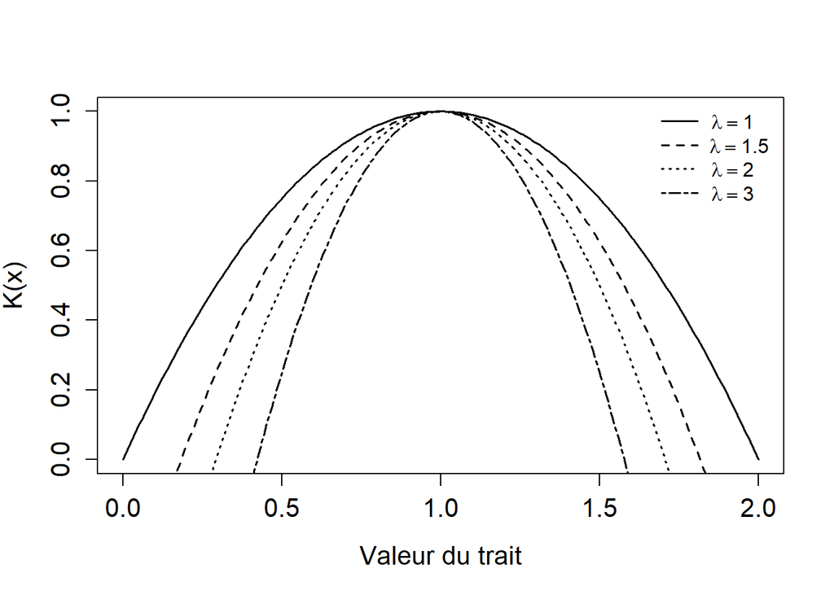

La valeur de $\lambda$ détermine la largeur de la courbe et donc le potentiel de répartition de l’utilisation de la ressource.

### — Fonction de compétition

On modélise l’intensité de la compétition entre deux phénotypes $x_i$ et $x_j$ basée sur la distance entre les traits ($x_1 - x_2$):
$$a(x_i, x_j) = e^{-\frac{1}{2}(x_i - x_j)^2/\sigma_a ^2}$$
L’idée est que plus des traits sont proches (i.e. $x_1 - x_2 \to 0$), plus la compétition sera intense car leur utilisation de la ressource se superposera.

```r
a_f <- function(x1, x2, sigma = 1) {

  a <- exp(-(1/2) * ((x1 - x2)^2)/ sigma)

  return(a)

}
```

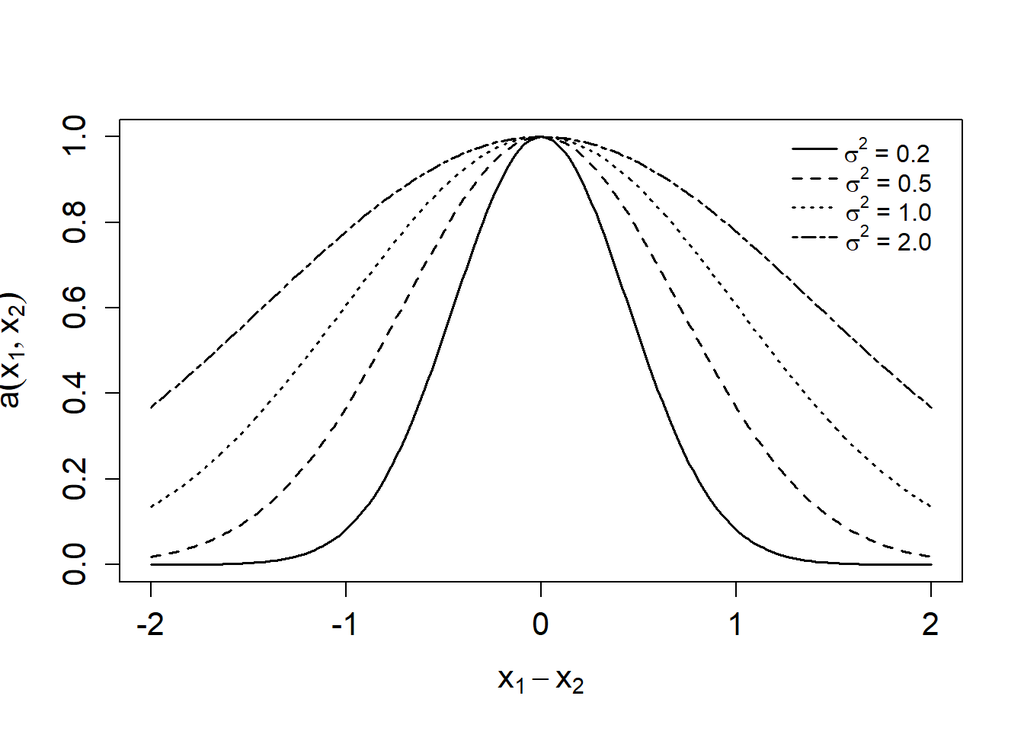

La paramètre $\sigma$ détermine l’intensité de la compétition. Plus il est élevée, plus la compétition est intense entre les phénotypes proches.

### — Fitness d’invasion

La fitness d’invasion $s(x_i, x_j)$ d’un mutant $x_i$ dans une population de $x_j$ est définie comme comme le taux de croissance attendu d’un mutant initialement rare dans la population de résident. Elle est définie par l’équation suivante :
$$s(x_i, x_j) = r \Bigg[ 1 - a(x_i, x_j) \frac{K(x_i)}{K(x_j)} \Bigg]$$
Par définition, $s(x_i, x_i) = 0$ (cas neutre). Si $s(x_i, x_j)<0$ alors le mutant s’éteint et si $s(x_i, x_j)>0$ le mutant peut envahir la population.

```r
fitness_f <- function(x1, x2){

  r = 1
  s <- r*(1 - (a_f(x1, x2) * (k_f(x1) / k_f(x2))))

  return(s)

}
```